# Lab 1: Welcome to RStudio

Instructor’s Solutions

September 13, 2021

### Objectives

In this lab we begin working in RStudio to examine data sets. In solving the exercises below, we practice how to

1. input and import data sets,
2. determine summary statistics,
3. present data visually, and
4. use *R Markdown* to write a lab report.

## SOLUTION to Q1:

### 1 a)

#### Code chunk(s)

```r
hank=c(13,27,26,44,30,39,40,34,45,44,24,32,44,39,29,44,38,47,34,40,20,12,10)
sum(hank)
```

```
## [1] 755
```

```r
max(hank)
```

```
## [1] 47
```

#### Written solution

Aaron hit 755 home runs in his career, and his highest season total was 47.

### 1 b)

#### Code chunk(s)

```r
fivenum(hank)
```

```
## [1] 10.0 26.5 34.0 42.0 47.0
```

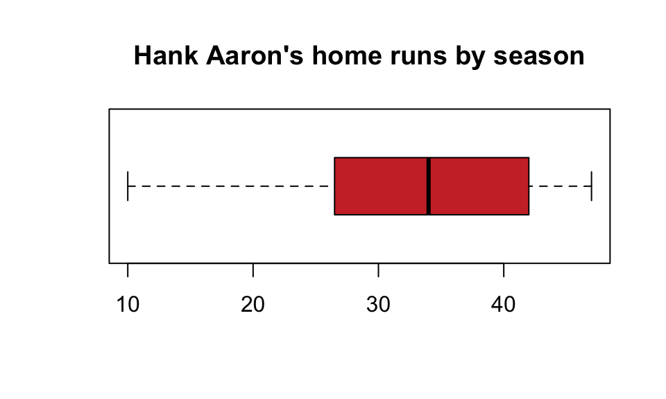

```r
boxplot(hank, horizontal=TRUE,col="brown3",main="Hank Aaron's home runs by season")
```

#### Written solution

The five number summary for Aaron’s home runs is 10, 26.5, 34, 42, 47, and the corresponding boxplot is pictured above.

### 1 c)

#### Code chunk(s)

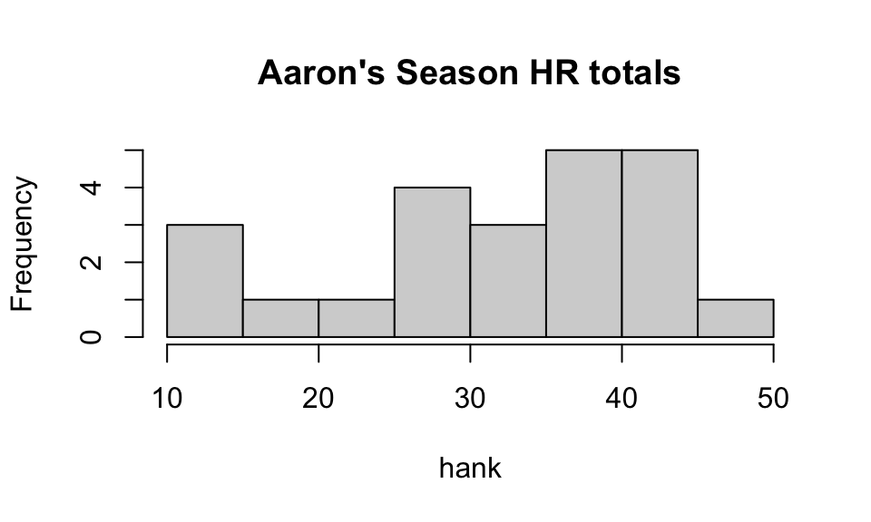

```r
hist(hank, main="Aaron's Season HR totals", breaks=10)
```

#### Written solution

Looking at the box plot in (b), this distribution is skewed left, since the whisker to the left is longer, and the distribution has no real outliers. Looking at the histogram, the distribution appears to be unimodal as well. In a typical season, Aaron hit around 34 home runs (34 is the median), and in half of his seasons he hit between 27 and 42.

## SOLUTION to Q2:

### 2 a)

#### Code chunk(s)

```r
storms=c(60,39,75,82,84,79,61,69,121,111,120,99,96,96,111,155,166)
sum(storms)
```

```
## [1] 1624
```

#### Written solution

There have been 1624 tropical storms reported since 1851.

### 2 b)

#### Code chunk(s)

```r
sum(storms)/170
```

```
## [1] 9.552941
```

#### Written solution

1624 storms in 170 years gives an average of about 9.6 storms per year.

### 2 c)

#### Code chunk(s)

```r
sum(storms[1:15])/150 #yearly avg over first 15 decades
```

```
## [1] 8.686667
```

```r
sum(storms[16:17])/20 #yearly avg over last 2 decades
```

```
## [1] 16.05
```

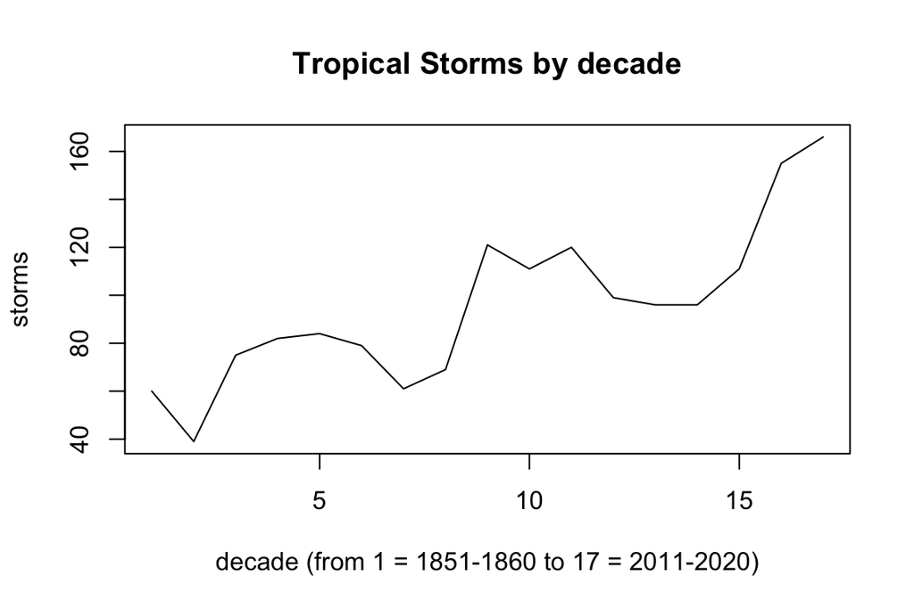

```r
plot(storms,type="l",xlab="decade (from 1 = 1851-1860 to 17 = 2011-2020)",ylab="storms",main="Tropical Storms by decade")
```

#### Written solution

The plot above clearly shows a positive trend. Also, on average, we recorded about 8.7 storms per year in the years prior to 2001, and about 16 storms per year in the last 20 years (2001-2020). Assuming the records are accurate, there seems to be good reason to consider the notion that storms are becoming more common.

## SOLUTION to Q3:

```r
survey <- read.csv("https://mphitchman.com/stats/data/survey_cleaned_F21.csv")
```

### 3 a)

#### Code chunk(s)

```r
dim(survey)
```

```
## [1] 58 17
```

### 3 b)

#### Code chunk(s)

```r
table(survey$abolishpenny)
```

```
##
##  No Yes
##  39  19
```

#### Written solution

In this survey 19 out of 58 respondents thought we should abolish the penny, giving a proportion 0.328 in favor of abolishing the penny.

### 3 c)

#### Code chunk(s)

```r
table(survey$eyecolor)
```

```
##
##  Blue Brown Green Hazel
##    18    22    10     8
```

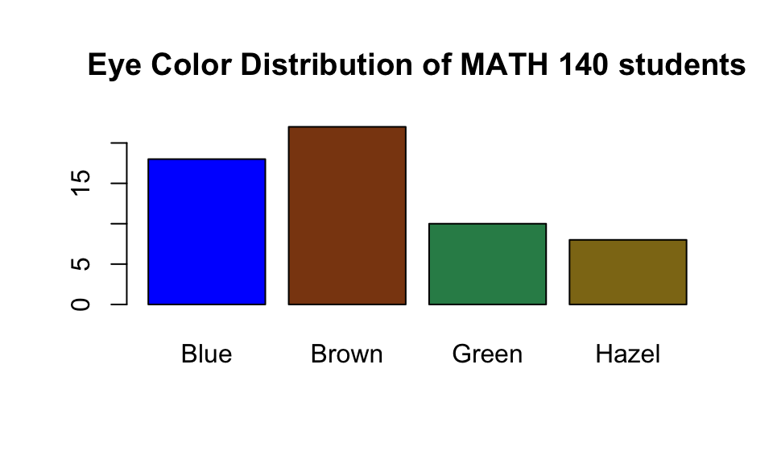

```r
barplot(table(survey$eyecolor),col=c("blue","saddlebrown","seagreen","#8e7618"),main="Eye Color Distribution of MATH 140 students")
```

#### Written solution

See above for the distribution of eye colors, and the barplot. Note that brown is the most common color.

### 3 d)

#### Code chunk(s)

```r
table(survey$randomnum)
```

```
##
##  2  3  4  5  6  7  8  9 10
##  4 10  5  5  6 12 10  4  2
```

#### Written solution

It looks like 10 respondents picked 8. Remembering that 1 was a possible choice in the question, we observe that 1 was chosen least as it was chosen 0 times.

Side note: Recalling the details of the survey question (namely that people could have answered 1-10), we can ask RStudio to tally all the possible choices as follows:

```r
table(factor(survey$randomnum, levels=1:10))
```

```
##
##  1  2  3  4  5  6  7  8  9 10
##  0  4 10  5  5  6 12 10  4  2
```

### 3 e)

#### Code chunk(s)

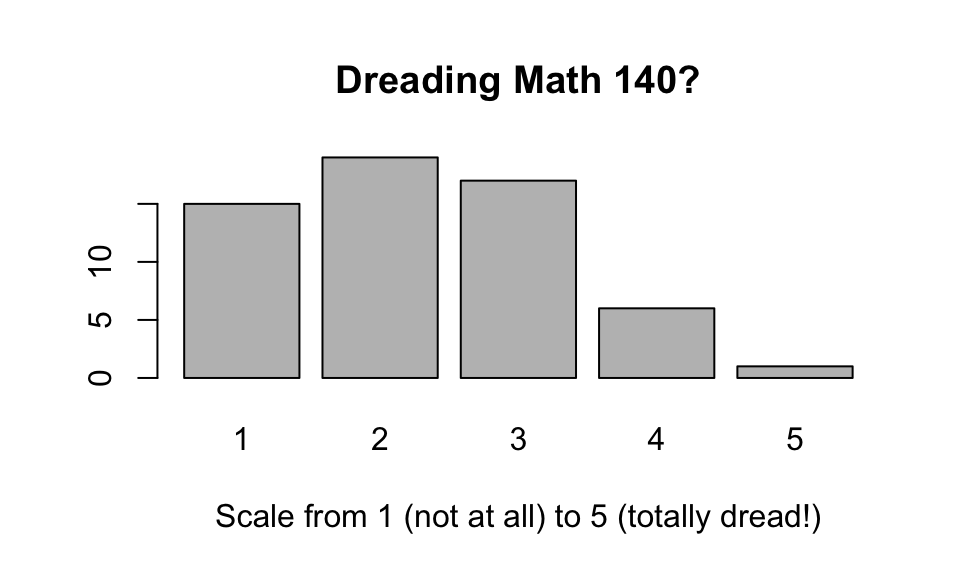

```r
barplot(table(survey$classdread),main="Dreading Math 140?",xlab="Scale from 1 (not at all) to 5 (totally dread!)")
```

#### Written solution

The distribution is slightly skewed right and unimodal. The mean response was 2.3, and 88% of the respondents had a dread level less than 4. On the whole, most students tended to answer in the “not dreading the class” end of the scale - only a few appeared to be really dreading it.

### 3 f)

#### Code chunk(s)

```r
table(survey$int.ext)
```

```
##
##             extroverted introverted
##           1          25          32
```

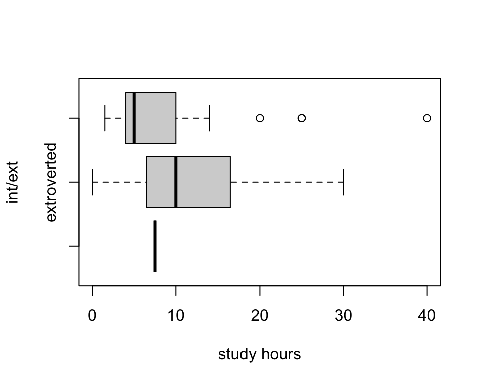

```r
boxplot(survey$studyhrs~survey$int.ext, horizontal=TRUE,xlab="study hours",ylab="int/ext")
```

#### Written solution

It looks as if one person chose not to answer this question, 32 respondents identified as introverted, and 25 as extroverted. In terms of the introverted and extroverted groups, there is a modest difference in the hours these groups plan to study.Although the introverted group has a few outliers on the high end, the distribution of study hours for the extroverted group tends to be higher than the introverted group. For instance, about 75% of the introverted group reported study hours less than or equal to the median for the extroverted group (10).

## SOLUTION to Q4:

```r
arb <- read.csv("https://www.openintro.org/data/csv/arbuthnot.csv")
```

### 4 a)

```r
nrow(arb)
```

```
## [1] 82
```

```r
variable.names(arb)
```

```
## [1] "year"  "boys"  "girls"
```

#### Written solution

The Arbuthnot data set has 82 observations (one for each year between 1629 and 1710), and three variables: “year”, “boys”, and “girls”.

### 4 b)

#### Code chunk(s)

```r
min(arb$boys)
```

```
## [1] 2890
```

```r
arb[arb$boys==min(arb$boys),1]
```

```
## [1] 1650
```

#### Written solution

The fewest number of boys baptized in London in a given year during this period was 2890, which occurred in 1650.

### 4 c)

#### Code chunk(s)

```r
arb$tot=arb$boys+arb$girls
min(arb$tot)
```

```
## [1] 5612
```

#### Written solution

The fewest number of children baptized in London in a given year during this period was 5612, which also occurred in 1650.

### 4 d)

#### Code chunk(s)

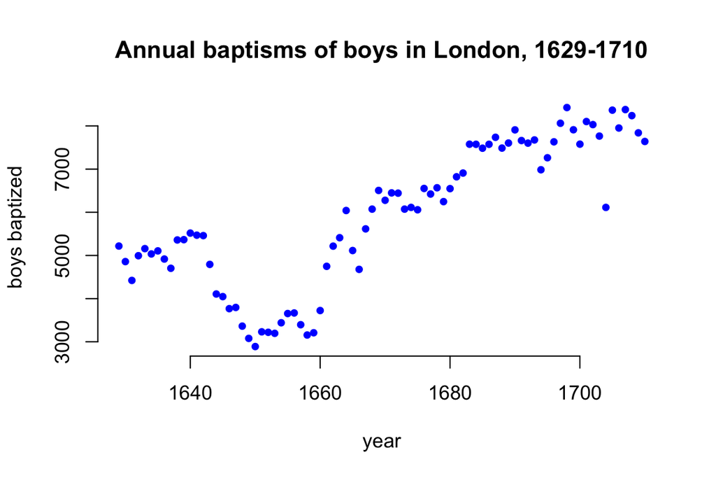

```r
plot(x=arb$year,y=arb$boys,xlab="year",ylab="boys baptized",
     frame = FALSE,
     main="Annual baptisms of boys in London, 1629-1710",
     pch = 19, col="blue",cex=0.7)
```

#### Written solution

There appears a general positive trend. Over time, more boys are generally being baptized in London, with a glaring exception of a dip in the years 1645-1661, which makes me curious to know what might have been the cause of this.

### 4 e)

#### Code chunk(s)

```r
arb[arb$year==1699,]
```

```
##    year boys girls   tot
## 71 1699 7911  7452 15363
```

```r
7911/15363
```

```
## [1] 0.5149385
```

#### Written solution

Of the 15363 children baptized in 1699, 7911 were boys, or about 51.5%.

### 4 f)

#### Code chunk(s)

```r
(boys=sum(arb$boys)) #putting parentheses around a variable being defined will cause the value to display when you run the cell.
```

```
## [1] 484382
```

```r
(girls=sum(arb$girls))
```

```
## [1] 453841
```

```r
(total=sum(arb$tot))
```

```
## [1] 938223
```

```r
(prop_boys = boys/total)
```

```
## [1] 0.516276
```

```r
(prop_girls = girls/total)
```

```
## [1] 0.483724
```

#### Written solution

All told 484,382 boys were baptized and 453,841 girls. So 51.6% of the baptisms were boys, 48.4% were girls.

### BONUS: 4 g)

#### Code chunk(s)

```r
arb$prop.boys <- arb$boys/(arb$boys+arb$girls)
```

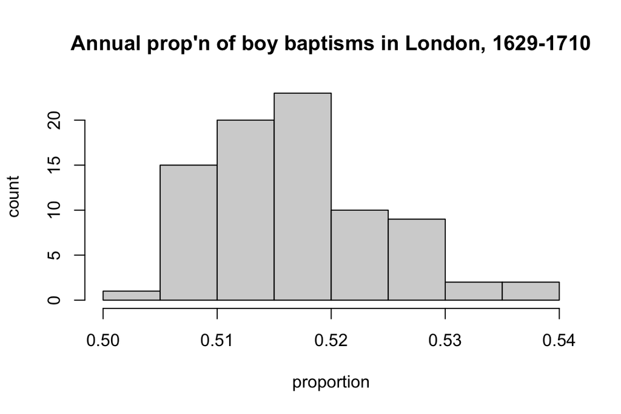

```r
hist(arb$prop.boys,breaks=8,xlab="proportion",
     ylab="count",main="Annual prop'n of boy baptisms in London, 1629-1710")
```

#### Written solution

Based on this histogram it is nearly certain that in any given year more boys were baptized in London than girls. In fact, in every one of these 82 years more boys were baptized than girls.